# Reproducible Research: Peer Assessment 1

Freddy Lazcano

December 14, 2016

## Loading and preprocessing the data

First we need to load the data and do any changes for our convinience when doing analysis, and load the package ggplot2

```r
#install.packages("ggplot2")
library(ggplot2)

Dclass<- c('numeric','character','integer')
InitialData <- read.csv("activity.csv", header = TRUE, colClasses = Dclass, na.strings = "NA")
# Change date field
InitialData$date <- as.Date(InitialData$date)

# Remove NA
ValidCount <- subset(InitialData, !is.na(InitialData$steps))
Stepsperday <- ValidCount[, c(1, 2)]
```

## What is mean total number of steps taken per day?

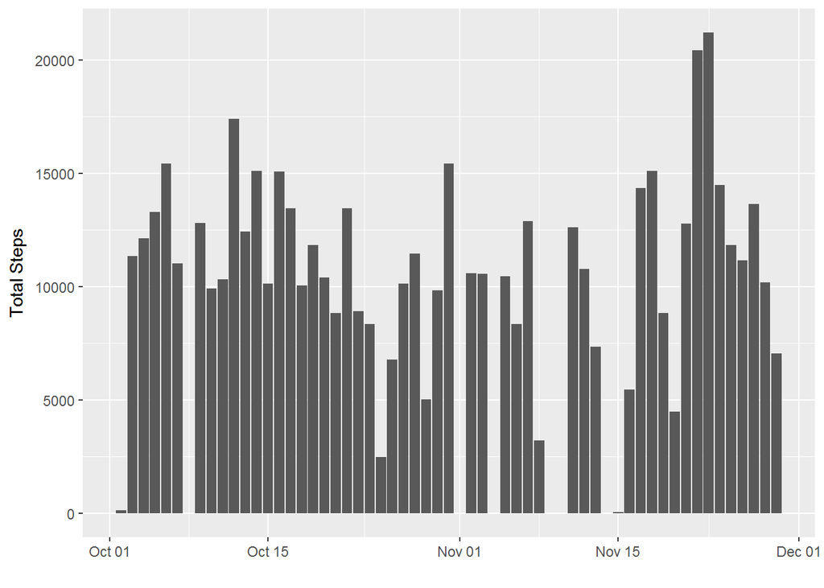

```r
graph1 <- ggplot(Stepsperday, aes(date, steps)) + geom_bar(stat = "identity") +
  scale_x_date() + xlab("") + ylab("Total Steps")
```

#### Mean & Median

```r
TStepsperday <- aggregate(steps ~ date, Stepsperday, FUN = sum)
  Mean1 <-  mean(TStepsperday$steps)
  Median1 <- median(TStepsperday$steps)
```

The Mean Total for steps taken by day:

```
## [1] 10766.19
```

The Median Total for steps taken by day:

```
## [1] 10765
```

## What is the average daily activity pattern?

1. Make a time series plot (i.e. type = “l”) of the 5-minute interval (x-axis) and the average number of steps taken, averaged across all days (y-axis)
2. Which 5-minute interval, on average across all the days in the dataset, contains the maximum number of steps?

#### Time series plot

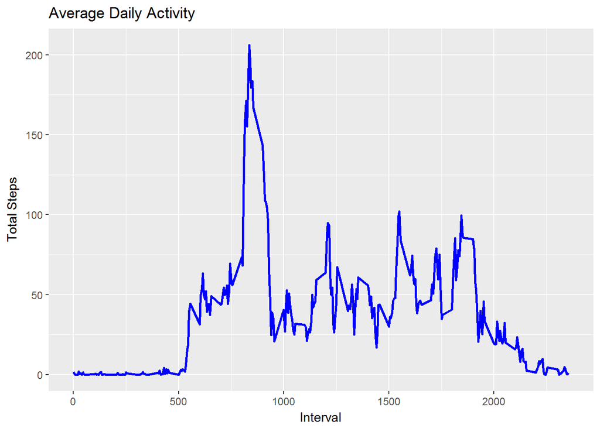

```r
Avg_per_int <-
  with(
    ValidCount[, c(1, 3)],
    aggregate(steps ~ interval, FUN = mean))

graph2 <- ggplot(Avg_per_int, aes(interval, steps)) + geom_line(size = 1, color = "blue") +
      xlab("Interval") + ylab("Total Steps") + ggtitle("Average Daily Activity" )
```

#### 5-min interval with more steps

```r
Avg_per_int[which.max(Avg_per_int$steps),]
```

```
##     interval    steps
## 104      835 206.1698
```